# 2026-11-19_p8157_hw-03

Chris

2026-11-19

```r
library(nlme)
library(knitr)
library(kableExtra)
library(geepack)

load("WtLoss.RData")
```

# 1 part a

```r
str(wtloss)
```

```
## 'data.frame':    997 obs. of  4 variables:
##  $ id    : int  1 1 1 1 1 1 1 1 1 2 ...
##  $ diet  : int  0 0 0 0 0 0 0 0 0 0 ...
##  $ time  : int  0 1 2 3 4 5 6 7 8 0 ...
##  $ weight: num  250 250 251 250 252 ...
```

```r
wtloss$diet <- factor(wtloss$diet, levels = c(0, 1, 2))
contrasts(wtloss$diet) <- contr.treatment(
  levels(wtloss$diet),
  base = 1
)

wtloss$id <- factor(wtloss$id)
wtloss <- wtloss[order(wtloss$id, wtloss$time), ]
```

```r
# Model (i): random intercept
fit_ri <- lme(
  fixed = weight ~ diet * time,
  random = ~ 1 | id,
  data = wtloss,
  method = "REML"
)


# Model (ii): correlated random intercept and time slope
fit_ris <- lme(
  fixed = weight ~ diet * time,
  random = ~ 1 + time | id,
  data = wtloss,
  method = "REML"
)
```

```r
summary(fit_ri)
```

```
## Linear mixed-effects model fit by REML
##   Data: wtloss
##        AIC      BIC    logLik
##   3538.857 3578.047 -1761.429
##
## Random effects:
##  Formula: ~1 | id
##         (Intercept) Residual
## StdDev:      2.9998 1.100762
##
## Fixed effects:  weight ~ diet * time
##                 Value Std.Error  DF  t-value p-value
## (Intercept) 250.94503 0.4860326 874 516.3132  0.0000
## diet1        -0.64537 0.6870571 117  -0.9393  0.3495
## diet2        -2.65991 0.6869325 117  -3.8722  0.0002
## time          0.04012 0.0244693 874   1.6395  0.1015
## diet1:time   -0.12421 0.0331682 874  -3.7448  0.0002
## diet2:time   -0.50072 0.0327534 874 -15.2877  0.0000
##  Correlation:
##            (Intr) diet1  diet2  time   dt1:tm
## diet1      -0.707
## diet2      -0.708  0.501
## time       -0.173  0.123  0.123
## diet1:time  0.128 -0.173 -0.090 -0.738
## diet2:time  0.129 -0.092 -0.172 -0.747  0.551
##
## Standardized Within-Group Residuals:
##         Min          Q1         Med          Q3         Max
## -3.70169455 -0.59428425 -0.02623782  0.60969242  3.01000216
##
## Number of Observations: 997
## Number of Groups: 120
```

```r
summary(fit_ris)
```

```
## Linear mixed-effects model fit by REML
##   Data: wtloss
##        AIC      BIC    logLik
##   3469.958 3518.945 -1724.979
##
## Random effects:
##  Formula: ~1 + time | id
##  Structure: General positive-definite, Log-Cholesky parametrization
##             StdDev    Corr
## (Intercept) 3.2002495 (Intr)
## time        0.1619474 -0.405
## Residual    1.0005626
##
## Fixed effects:  weight ~ diet * time
##                 Value Std.Error  DF  t-value p-value
## (Intercept) 250.99189 0.5158952 874 486.5172  0.0000
## diet1        -0.69659 0.7292397 117  -0.9552  0.3414
## diet2        -2.68749 0.7291456 117  -3.6858  0.0003
## time          0.01884 0.0366412 874   0.5143  0.6072
## diet1:time   -0.10216 0.0505652 874  -2.0204  0.0436
## diet2:time   -0.49129 0.0503348 874  -9.7605  0.0000
##  Correlation:
##            (Intr) diet1  diet2  time   dt1:tm
## diet1      -0.707
## diet2      -0.708  0.501
## time       -0.388  0.275  0.275
## diet1:time  0.281 -0.391 -0.199 -0.725
## diet2:time  0.283 -0.200 -0.392 -0.728  0.527
##
## Standardized Within-Group Residuals:
##          Min           Q1          Med           Q3          Max
## -3.470223738 -0.600200758 -0.003836862  0.587942728  2.990926601
##
## Number of Observations: 997
## Number of Groups: 120
```

```r
VarCorr(fit_ri)
```

```
## id = pdLogChol(1)
##             Variance StdDev
## (Intercept) 8.998800 2.999800
## Residual    1.211678 1.100762
```

```r
VarCorr(fit_ris)
```

```
## id = pdLogChol(1 + time)
##             Variance    StdDev    Corr
## (Intercept) 10.24159697 3.2002495 (Intr)
## time         0.02622695 0.1619474 -0.405
## Residual     1.00112549 1.0005626
```

```r
intervals(fit_ri, which = "fixed")
```

```
## Approximate 95% confidence intervals
##
##  Fixed effects:
##                     lower         est.        upper
## (Intercept) 249.991106711 250.94503403 251.89896135
## diet1        -2.006055289  -0.64537480   0.71530570
## diet2        -4.020342767  -2.65990897  -1.29947517
## time         -0.007907927   0.04011746   0.08814285
## diet1:time   -0.189305209  -0.12420664  -0.05910807
## diet2:time   -0.565008723  -0.50072419  -0.43643966
```

```r
intervals(fit_ris, which = "fixed")
```

```
## Approximate 95% confidence intervals
##
##  Fixed effects:
##                    lower         est.         upper
## (Intercept) 249.97935204 250.99189027 252.004428499
## diet1        -2.14081326  -0.69659234   0.747628589
## diet2        -4.13152787  -2.68749331  -1.243458744
## time         -0.05306998   0.01884495   0.090759887
## diet1:time   -0.20140655  -0.10216321  -0.002919876
## diet2:time   -0.59008596  -0.49129479  -0.392503620
```

```r
# Random-effects covariance and correlation matrices
G_ris <- as.matrix(
  getVarCov(fit_ris, type = "random.effects")
)

G_ris
```

```
## Random effects variance covariance matrix
##             (Intercept)      time
## (Intercept)    10.24200 -0.209850
## time           -0.20985  0.026227
##   Standard Deviations: 3.2002 0.16195
```

```r
cov2cor(G_ris)
```

```
## Random effects variance covariance matrix
##             (Intercept)     time
## (Intercept)     1.00000 -0.40491
## time           -0.40491  1.00000
##   Standard Deviations: 1 1
```

```r
# Residual variance
sigma(fit_ris)^2
```

```
## [1] 1.001125
```

Linear mixed-effects models of weight over time.

| Parameter | Random intercept Estimate (95% CI) | Random intercept p value | Random intercept and slope Estimate (95% CI) | Random intercept and slope p value |
| --- | --- | --- | --- | --- |
| **Fixed effects** |  |  |  |  |
| Baseline mean: diet 0 | 250.945 (249.991, 251.899) | <0.001 | 250.992 (249.979, 252.004) | <0.001 |
| Baseline difference: diet 1 vs 0 | -0.645 (-2.006, 0.715) | 0.349 | -0.697 (-2.141, 0.748) | 0.341 |
| Baseline difference: diet 2 vs 0 | -2.660 (-4.020, -1.299) | <0.001 | -2.687 (-4.132, -1.243) | <0.001 |
| Monthly change: diet 0 | 0.040 (-0.008, 0.088) | 0.101 | 0.019 (-0.053, 0.091) | 0.607 |
| Slope difference: diet 1 vs 0 | -0.124 (-0.189, -0.059) | <0.001 | -0.102 (-0.201, -0.003) | 0.044 |
| Slope difference: diet 2 vs 0 | -0.501 (-0.565, -0.436) | <0.001 | -0.491 (-0.590, -0.393) | <0.001 |
| **Variance components** |  |  |  |  |
| Random-intercept variance | 8.9988 |  | 10.2416 |  |
| Random-slope variance | – |  | 0.0262 |  |
| Intercept-slope covariance | – |  | -0.2099 |  |
| Intercept-slope correlation | – |  | -0.4049 |  |
| Residual variance | 1.2117 |  | 1.0011 |  |

Notes: Both models were fitted by REML using 997 observations from 120 patients. Time is in months; month 0 is baseline. Diet 0 is the reference group: baseline counseling only; diet 1: counseling at all visits; diet 2: counseling at all visits plus free exercise-facility access. Fixed effects are estimates (95% CIs) with model-based t-test p values. Variance components and the correlation are point estimates only. A dash indicates a parameter absent from model (i). Weight is reported in the original, unspecified measurement units.

Let $D_{1k}=I(\mathrm{diet}_k=1)$ and $D_{2k}=I(\mathrm{diet}_k=2)$. The model is
$$\begin{aligned}
Y_{ki} ={}&
\beta_0^*+\beta_1^*D_{1k}+\beta_2^*D_{2k}
+\beta_3^*t_{ki}
+\beta_4^*D_{1k}t_{ki}
+\beta_5^*D_{2k}t_{ki}\\
&+\gamma_{0k}+\gamma_{1k}t_{ki}+\epsilon_{ki},
\end{aligned}$$
where
$$\begin{pmatrix}
\gamma_{0k}\\
\gamma_{1k}
\end{pmatrix}
\sim N\left[
\begin{pmatrix}0\\0\end{pmatrix},
G
\right],
\qquad
\epsilon_{ki}\sim N(0,\sigma_\epsilon^2).$$
Random effects and residual errors are independent, and patients are independent of one another.

The treatment-specific slopes were calculated before rounding. They imply estimated average weight losses of 0.083 and 0.472 units per month in diets 1 and 2, respectively.

The interaction coefficients represent differences between slopes. Their $p$ values test these differences relative to diet 0, rather than testing whether each treatment group’s own slope equals zero.

Because the model uses an identity link and mean-zero random effects, the fixed-effect trajectories also describe population mean trajectories within each treatment group. Individual trajectories vary around these means through the random intercept and slope.

The estimated random-effects covariance matrix was
$$\widehat{G}=
\begin{pmatrix}
10.2416 & -0.2099\\
-0.2099 & 0.0262
\end{pmatrix},
\qquad
\widehat{\sigma}_\epsilon^2=1.0011.$$

The intercept and residual variances have units of squared weight units; the slope variance has units of squared weight units per month squared; and the intercept–slope covariance has units of squared weight units per month. The correlation is dimensionless.

# 2 part b

```r
# Use the default simulation algorithm and save the results.
cache_file <- "Q1b_default_REML_seed1504.rds"

if (file.exists(cache_file)) {
  sim_b <- readRDS(cache_file)
} else {
  sim_b <- simulate.lme(
    object = fit_ri,
    m2 = fit_ris,
    nsim = 1000,
    seed = 1504,
    method = "REML"
  )

  saveRDS(sim_b, cache_file)
}

null_fit <- sim_b$null$REML
alt_fit <- sim_b$alt$REML

table(
  Null = null_fit[, "info"],
  Alternative = alt_fit[, "info"]
)
```

```
##     Alternative
## Null    0
##    0 1000
```

```r
# Follow the statistic construction in plot.simulate.lme().
ok <- null_fit[, "info"] == 0 &
      alt_fit[, "info"] == 0 &
      is.finite(null_fit[, "logLik"]) &
      is.finite(alt_fit[, "logLik"])

if (!all(ok)) {
  warning("Only converged simulations are used; inspect the reported count.")
}

T_sim <- 2 * pmax(
  0,
  alt_fit[ok, "logLik"] - null_fit[ok, "logLik"]
)

T_obs <- 2 * as.numeric(
  logLik(fit_ris) - logLik(fit_ri)
)

q95 <- c(
  Simulated = unname(quantile(T_sim, 0.95)),
  Chi_square_1 = qchisq(0.95, df = 1),
  Chi_square_2 = qchisq(0.95, df = 2)
)

critical_values <- data.frame(
  Distribution = names(q95),
  Percentile_95 = unname(q95)
)

test_results <- data.frame(
  Observed_RLRT = T_obs,
  Simulations_used = length(T_sim),
  Bootstrap_p =
    (1 + sum(T_sim >= T_obs)) / (length(T_sim) + 1)
)

critical_values
```

```
##   Distribution Percentile_95
## 1    Simulated      4.528915
## 2 Chi_square_1      3.841459
## 3 Chi_square_2      5.991465
```

```r
test_results
```

```
##   Observed_RLRT Simulations_used Bootstrap_p
## 1      72.89912             1000 0.000999001
```

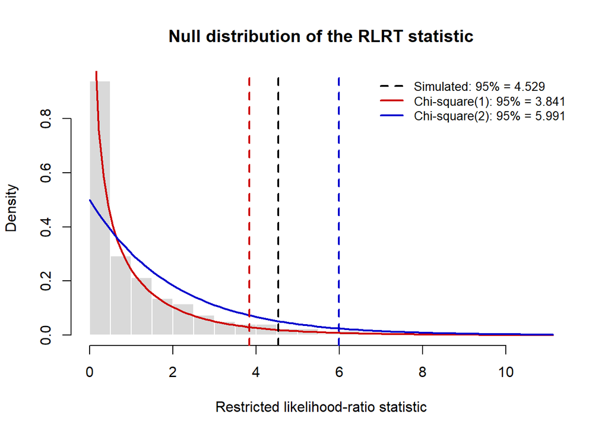

```r
# Plot the simulated distribution and theoretical densities.
hist(
  T_sim,
  breaks = 30,
  probability = TRUE,
  col = "grey85",
  border = "white",
  xlim = c(0, max(T_sim, qchisq(0.995, 2))),
  main = "Null distribution of the RLRT statistic",
  xlab = "Restricted likelihood-ratio statistic",
  ylab = "Density"
)

curve(
  dchisq(x, df = 1),
  from = 0.001,
  add = TRUE,
  col = "red3",
  lwd = 2
)

curve(
  dchisq(x, df = 2),
  from = 0,
  add = TRUE,
  col = "blue3",
  lwd = 2
)

abline(
  v = q95,
  col = c("black", "red3", "blue3"),
  lty = 2,
  lwd = 2
)

legend(
  "topright",
  legend = sprintf(
    c(
      "Simulated: 95%% = %.3f",
      "Chi-square(1): 95%% = %.3f",
      "Chi-square(2): 95%% = %.3f"
    ),
    q95
  ),
  col = c("black", "red3", "blue3"),
  lty = c(2, 1, 1),
  lwd = 2,
  bty = "n",
  cex = 0.85
)
```

Let $\sigma_1^2$ denote the variance of the random time slope and $\sigma_{01}$ the covariance between the random intercept and slope. We tested
$$H_0:\sigma_1^2=0
\quad\text{versus}\quad
H_A:\sigma_1^2>0.$$
Under $H_0$, positive semidefiniteness of the random-effects covariance matrix also requires $\sigma_{01}=0$. Under $H_A$, this covariance is estimated without being restricted to zero.

This is a nonstandard testing problem because a variance of zero lies on the boundary of the parameter space. For this model comparison, the asymptotic reference distribution is
$$\frac{1}{2}\chi_1^2+\frac{1}{2}\chi_2^2,$$
rather than a conventional chi-square distribution based solely on the number of additional parameters.

We used to generate 1,000 datasets under the fitted random-intercept model, with seed 1504. Both models were fitted by REML to each simulated dataset. The observed restricted likelihood-ratio statistic was
$$T_{\mathrm{obs}}
=
2\left\{
\ell_R(\widehat{\theta}_{\mathrm{RIS}})
-
\ell_R(\widehat{\theta}_{\mathrm{RI}})
\right\}
=
72.899.$$

The simulated null distribution was right-skewed. Its estimated 95th percentile was 4.529, between the corresponding percentiles of the $\chi_1^2$ and $\chi_2^2$ distributions, 3.841 and 5.991, respectively. Relative to the simulated critical value, using $\chi_1^2$ alone would give a lower rejection threshold, whereas using $\chi_2^2$ alone would give a higher threshold.

The observed statistic was substantially greater than the simulated 95th percentile. None of the 1,000 simulated statistics was as large as the observed statistic. Using the Monte Carlo correction, the estimated bootstrap $p$ value was
$$\widehat{p}
=
\frac{1+\sum_{b=1}^{1000}
I(T_b\geq T_{\mathrm{obs}})}
{1000+1}
=
\frac{1}{1001}
\approx 0.001.$$

We therefore reject $H_0$ at the 5% significance level. The random-intercept and random-slope model provides a significantly better fit than the random-intercept-only model. After accounting for treatment group and its interaction with time, patients still differ in their rates of weight change. The random-intercept-only model is therefore inadequate to describe this between-patient variation in longitudinal trajectories.

# 3 part c

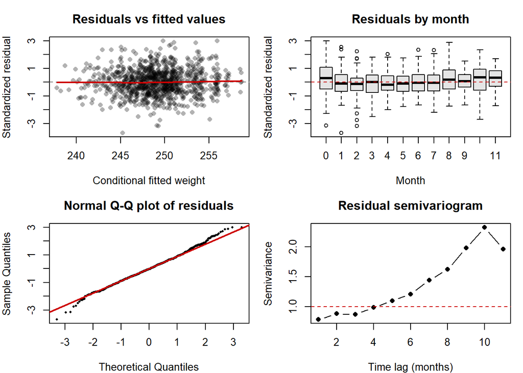

```r
# Conditional standardized residuals
diag_data <- getData(fit_ri)

diag_data$fitted <- as.numeric(
  fitted(fit_ri, level = 1)
)

diag_data$residual <- as.numeric(
  residuals(fit_ri, level = 1, type = "pearson")
)

vg <- Variogram(
  fit_ri,
  form = ~ time | id,
  resType = "pearson"
)

old_par <- par(
  mfrow = c(2, 2),
  mar = c(4, 4, 3, 1)
)


# Residuals versus fitted values
plot(
  diag_data$fitted,
  diag_data$residual,
  pch = 16,
  col = adjustcolor("black", alpha.f = 0.3),
  xlab = "Conditional fitted weight",
  ylab = "Standardized residual",
  main = "Residuals vs fitted values"
)

abline(h = 0, col = "grey50", lty = 2)

lines(
  lowess(diag_data$fitted, diag_data$residual),
  col = "red3",
  lwd = 2
)


# Residual distribution over time
boxplot(
  residual ~ time,
  data = diag_data,
  col = "grey90",
  xlab = "Month",
  ylab = "Standardized residual",
  main = "Residuals by month"
)

abline(h = 0, col = "red3", lty = 2)


# Residual normality
qqnorm(
  diag_data$residual,
  pch = 16,
  cex = 0.5,
  main = "Normal Q-Q plot of residuals"
)

qqline(
  diag_data$residual,
  col = "red3",
  lwd = 2
)


# Within-patient residual dependence
plot(
  vg$dist,
  vg$variog,
  type = "b",
  pch = 16,
  xlab = "Time lag (months)",
  ylab = "Semivariance",
  main = "Residual semivariogram"
)

abline(h = 1, col = "red3", lty = 2)
```

```r
par(old_par)

vg[, c("dist", "variog", "n.pairs")]
```

```
##    dist    variog n.pairs
## 1     1 0.7844500     877
## 2     2 0.8824390     757
## 3     3 0.8715835     637
## 4     4 0.9879731     517
## 5     5 1.1009348     397
## 6     6 1.2111396     294
## 7     7 1.4453464     207
## 8     8 1.6250914     135
## 9     9 1.9785888      81
## 10   10 2.3278288      41
## 11   11 1.9650817      15
```

The standardized conditional residuals were generally centered near zero, and the residual-versus-fitted plot showed no strong systematic trend or pronounced funnel shape. The monthly boxplots showed some differences in residual location and spread. The normal Q–Q plot was approximately linear, with modest departures in the tails and a few extreme residuals, suggesting that normality was broadly reasonable.

The residual semivariogram, however, showed a clear increase with time lag. The estimated semivariance increased from 0.784 at a one-month lag to 2.328 at a ten-month lag. Under the random-intercept model with independent, homoscedastic residual errors, the standardized residual semivariogram would be expected to be approximately flat near 1. The observed pattern therefore suggests that the model does not adequately capture the within-patient covariance structure. Estimates at the longest lags are less precise because they are based on relatively few pairs, particularly 41 pairs at ten months and 15 pairs at eleven months.

These findings are consistent with part (b), where the random-intercept-only model was rejected in favor of the random-intercept and random-slope model ($T_{\mathrm{obs}}=72.899$, bootstrap $p\approx0.001$). The increasing semivariance is consistent with unmodeled between-patient variation in rates of weight change, supporting the inclusion of random time slopes.

# 4 part d

```r
gee_data <- wtloss[order(wtloss$id, wtloss$time), ]

gee_data$id <- factor(gee_data$id)
gee_data$diet <- factor(
  gee_data$diet,
  levels = c(0, 1, 2)
)

contrasts(gee_data$diet) <- contr.treatment(
  levels(gee_data$diet),
  base = 1
)

gee_data$visit <- gee_data$time + 1L


# Working independence
fit_gee_i <- geeglm(
  weight ~ diet * time,
  id = id,
  waves = visit,
  data = gee_data,
  family = gaussian(link = "identity"),
  corstr = "independence",
  scale.fix = FALSE,
  std.err = "san.se"
)


# Working exchangeable
fit_gee_e <- geeglm(
  weight ~ diet * time,
  id = id,
  waves = visit,
  data = gee_data,
  family = gaussian(link = "identity"),
  corstr = "exchangeable",
  scale.fix = FALSE,
  std.err = "san.se"
)


# Working AR(1)
fit_gee_ar1 <- geeglm(
  weight ~ diet * time,
  id = id,
  waves = visit,
  data = gee_data,
  family = gaussian(link = "identity"),
  corstr = "ar1",
  scale.fix = FALSE,
  std.err = "san.se"
)

summary(fit_gee_i)
```

```
##
## Call:
## geeglm(formula = weight ~ diet * time, family = gaussian(link = "identity"),
##     data = gee_data, id = id, waves = visit, corstr = "independence",
##     scale.fix = FALSE, std.err = "san.se")
##
##  Coefficients:
##               Estimate    Std.err      Wald Pr(>|W|)
## (Intercept) 251.017403   0.581142 1.866e+05  < 2e-16 ***
## diet1        -0.861213   0.755270 1.300e+00 0.254173
## diet2        -2.809085   0.784815 1.281e+01 0.000345 ***
## time         -0.016014   0.082410 3.800e-02 0.845927
## diet1:time    0.008145   0.098507 7.000e-03 0.934099
## diet2:time   -0.400459   0.104703 1.463e+01 0.000131 ***
## ---
## Signif. codes:  0 '***' 0.001 '**' 0.01 '*' 0.05 '.' 0.1 ' ' 1
##
## Correlation structure = independence
## Estimated Scale Parameters:
##
##             Estimate Std.err
## (Intercept)    9.779   1.071
## Number of clusters:   120  Maximum cluster size: 12
```

```r
summary(fit_gee_e)
```

```
##
## Call:
## geeglm(formula = weight ~ diet * time, family = gaussian(link = "identity"),
##     data = gee_data, id = id, waves = visit, corstr = "exchangeable",
##     scale.fix = FALSE, std.err = "san.se")
##
##  Coefficients:
##             Estimate  Std.err     Wald Pr(>|W|)
## (Intercept) 250.9455   0.5588 2.02e+05  < 2e-16 ***
## diet1        -0.6464   0.7362 7.70e-01  0.37992
## diet2        -2.6607   0.7484 1.26e+01  0.00038 ***
## time          0.0398   0.0348 1.31e+00  0.25313
## diet1:time   -0.1235   0.0549 5.07e+00  0.02434 *
## diet2:time   -0.5002   0.0502 9.92e+01  < 2e-16 ***
## ---
## Signif. codes:  0 '***' 0.001 '**' 0.01 '*' 0.05 '.' 0.1 ' ' 1
##
## Correlation structure = exchangeable
## Estimated Scale Parameters:
##
##             Estimate Std.err
## (Intercept)     9.83    1.08
##   Link = identity
##
## Estimated Correlation Parameters:
##       Estimate Std.err
## alpha    0.858   0.037
## Number of clusters:   120  Maximum cluster size: 12
```

```r
summary(fit_gee_ar1)
```

```
##
## Call:
## geeglm(formula = weight ~ diet * time, family = gaussian(link = "identity"),
##     data = gee_data, id = id, waves = visit, corstr = "ar1",
##     scale.fix = FALSE, std.err = "san.se")
##
##  Coefficients:
##              Estimate   Std.err     Wald Pr(>|W|)
## (Intercept) 251.12925   0.58331 1.85e+05   <2e-16 ***
## diet1        -0.70267   0.78440 8.00e-01   0.3704
## diet2        -2.24942   0.79992 7.91e+00   0.0049 **
## time          0.00989   0.04236 5.00e-02   0.8155
## diet1:time   -0.11810   0.06008 3.86e+00   0.0493 *
## diet2:time   -0.52145   0.05582 8.73e+01   <2e-16 ***
## ---
## Signif. codes:  0 '***' 0.001 '**' 0.01 '*' 0.05 '.' 0.1 ' ' 1
##
## Correlation structure = ar1
## Estimated Scale Parameters:
##
##             Estimate Std.err
## (Intercept)     9.88    1.08
##   Link = identity
##
## Estimated Correlation Parameters:
##       Estimate Std.err
## alpha    0.963   0.014
## Number of clusters:   120  Maximum cluster size: 12
```

GEE estimates of weight trajectories under three working correlation structures.

| Parameter | GEE-I | GEE-E | GEE-AR1 |
| --- | --- | --- | --- |
| **Regression parameters** |  |  |  |
| Baseline mean: diet 0 | 251.0174 (249.8784, 252.1564) | 250.9455 (249.8502, 252.0407) | 251.1293 (249.9860, 252.2725) |
| Baseline difference: diet 1 vs 0 | -0.8612 (-2.3415, 0.6191) | -0.6464 (-2.0892, 0.7965) | -0.7027 (-2.2401, 0.8347) |
| Baseline difference: diet 2 vs 0 | -2.8091 (-4.3473, -1.2709) | -2.6607 (-4.1276, -1.1938) | -2.2494 (-3.8172, -0.6816) |
| Monthly change: diet 0 | -0.0160 (-0.1775, 0.1455) | 0.0398 (-0.0285, 0.1081) | 0.0099 (-0.0731, 0.0929) |
| Slope difference: diet 1 vs 0 | 0.0081 (-0.1849, 0.2012) | -0.1235 (-0.2311, -0.0160) | -0.1181 (-0.2359, -0.0003) |
| Slope difference: diet 2 vs 0 | -0.4005 (-0.6057, -0.1952) | -0.5002 (-0.5986, -0.4018) | -0.5215 (-0.6309, -0.4121) |
| **Working covariance parameters** |  |  |  |
| Working correlation parameter | 0.0000 | 0.8583 | 0.9631 |
| Dispersion parameter | 9.7790 | 9.8273 | 9.8830 |

Notes: GEE-I, working independence; GEE-E, working exchangeable; GEE-AR1, working first-order autoregressive correlation. All models used an identity link and the same mean model, with 997 observations from 120 patients. Regression entries are estimates (95% robust sandwich Wald CIs). Working covariance parameters are point estimates only. Diet 0 is the reference: baseline counseling only; diet 1: counseling at all visits; diet 2: counseling at all visits plus free exercise-facility access. Time is in months, with month 0 representing baseline. For GEE-AR1, the correlation parameter refers to a one-month lag; for GEE-I it is fixed at zero. Weight is reported in the original, unspecified measurement units.

For the GEE-E analysis, the marginal mean model was
$$\begin{aligned}
E(Y_{ki}\mid D_{1k},D_{2k},t_{ki})
={}&\beta_0+\beta_1D_{1k}+\beta_2D_{2k}
+\beta_3t_{ki}\\
&+\beta_4D_{1k}t_{ki}
+\beta_5D_{2k}t_{ki},
\end{aligned}$$
where $D_{1k}=I(\mathrm{diet}_k=1)$ and $D_{2k}=I(\mathrm{diet}_k=2)$. Diet 0 was the reference group, and $t=0$ represented baseline. Confidence intervals and $p$ values were based on robust sandwich standard errors.

Thus, the estimated population mean trajectories corresponded to average monthly weight losses of approximately 0.084 and 0.460 units in diets 1 and 2, respectively. The interaction coefficients represent differences between treatment-specific slopes; their $p$ values do not test whether each group’s own slope equals zero.

The estimated exchangeable working correlation was 0.8583, indicating strong within-patient association under a working model that assigns the same correlation to every pair of measurements from the same patient.

# 5 part e

```r
# Joint robust Wald test of the diet-by-time interactions.
interaction_terms <- c("diet1:time", "diet2:time")

b <- coef(fit_gee_e)[interaction_terms]

V <- vcov(fit_gee_e)[
  interaction_terms,
  interaction_terms,
  drop = FALSE
]

wald_stat <- as.numeric(
  t(b) %*% solve(V, b)
)

df <- length(b)

p_value <- pchisq(
  wald_stat,
  df = df,
  lower.tail = FALSE
)

wald_results <- data.frame(
  Wald_statistic = wald_stat,
  df = df,
  p_value = p_value
)

wald_results
```

```
##   Wald_statistic df  p_value
## 1            105  2 1.71e-23
```

```r
# Estimated population mean weight change per month.
beta <- coef(fit_gee_e)

slope_results <- data.frame(
  Diet = c("0", "1", "2"),
  Monthly_weight_change = c(
    beta["time"],
    beta["time"] + beta["diet1:time"],
    beta["time"] + beta["diet2:time"]
  ),
  row.names = NULL
)

slope_results
```

```
##   Diet Monthly_weight_change
## 1    0                0.0398
## 2    1               -0.0837
## 3    2               -0.4604
```

We tested whether the population mean rates of weight change were equal across the three treatment groups:
$$H_0:\beta_4=\beta_5=0
\quad\text{versus}\quad
H_A:\text{at least one of }\beta_4,\beta_5
\text{ is nonzero}.$$

Using the GEE-E estimates and their robust sandwich covariance matrix, the joint Wald test gave
$$W\approx105,\qquad df=2,\qquad
p=1.71\times10^{-23}.$$
We therefore reject $H_0$ and conclude that the average rate of weight change differs among the treatment groups.

For a non-biostatistician collaborator, these results can be summarized as follows:

There is strong evidence that the treatment groups had different average weight-change rates. Patients receiving counseling only at baseline had an estimated average weight increase of 0.0398 units per month. Patients receiving counseling at every visit had an estimated average weight loss of 0.0837 units per month, while those also offered free access to an exercise facility had an estimated average weight loss of 0.4604 units per month. The largest estimated average weight loss was therefore observed in the counseling-plus-exercise group. These are population averages; individual patients may have different weight-change patterns.

# 6 part f

Assuming the mean model is correctly specified, independent patients, and the usual regularity and observation-process conditions, consistency of the regression estimates must be distinguished from validity of their standard errors.

For these identity-link linear models, the fixed-effect estimating equations have expectation zero under the correct mean model, even if the covariance structure is misspecified. Thus, the fixed-effect estimates from both the random-intercept and random-intercept/random-slope models can remain consistent.

However, reports model-based standard errors, whose validity depends on the covariance specification. Parts (b) and (c) provided evidence that the random-intercept-only covariance structure was inadequate. Its reported standard errors therefore cannot be assumed valid, even though its fixed-effect estimates may remain consistent. The random-intercept/random-slope model has valid model-based standard errors if its covariance structure is correctly specified. Its improved fit does not establish that every covariance assumption is correct.

Correct specification of the mean alone also does not guarantee consistent estimation of the true variance components under a misspecified covariance model.

The regression estimates from GEE-I, GEE-E, and GEE-AR1 are consistent under the correct mean model, even when their working correlation structures are incorrect. The standard errors reported in part (d) were robust sandwich standard errors, which are asymptotically valid under working covariance misspecification.

The working correlation structure affects efficiency, so the three methods can produce different estimates and standard errors in this finite sample without contradicting their consistency. These asymptotic results depend primarily on the number of independent patients, here $K=120$, rather than the total of 997 observations.

If follow-up is incomplete, missingness assumptions are also required. MCAR is a sufficient condition for the usual unweighted GEE analysis, whereas validity is not generally guaranteed under MAR without additional adjustment. A correctly specified likelihood-based model can support valid inference under MAR when the response-model and missingness-model parameters are distinct. Consequently, correct specification of the mean alone does not guarantee validity under arbitrary missingness.